# Richness by combined zones

### Richness data frames

Convert rasters to dataframes of richness by ANP zone, biome, land cover, and pollinator group.

```r
# Load stacked zones
combo_ras <- terra::rast(zones_ras_fp)

rich_dir <- file.path(pred_dir, 'richness')
div_df <- create_richness_df(rich_dir, div_dir, zones_lu_fp, combo_ras, overwrite = FALSE)
div_df <- div_df %>%
  mutate(biome = factor(biome, levels = bioms_english_sorted),
         pol_group = factor(pol_group,
                            levels = c('bee', 'butterfly', 'moth',
                                       'bat', 'hummingbird', 'fly', 'wasp')))
```

#### Richness by pollinator group

```r
div_df %>%
  group_by(pol_group) %>%
  summarise(mean = mean(richness, na.rm = TRUE),
            median = median(richness),
            min = min(richness, na.rm = TRUE),
            max = max(richness, na.rm = TRUE)) %>%
  arrange(desc(mean))
```

```
## # A tibble: 7 x 5
##   pol_group      mean   median    min    max
##   <fct>         <dbl>    <dbl>  <dbl>  <dbl>
## 1 butterfly   25.8    12.7     0.208  249.
## 2 bee          7.68    5.75    0.293   70.1
## 3 moth         6.61    3.50    0.0210 121.
## 4 bat          1.19    0.805   0        6.85
## 5 fly          0.0851  0.0270  0        4.53
## 6 hummingbird  0.0623  0.00400 0        3.04
## 7 wasp         0.0115  0       0        1.32
```

#### Richness in each ecoregion

```r
div_df %>%
  group_by(biome, pol_group) %>%
  summarise(mean = mean(richness, na.rm = TRUE),
            median = median(richness),
            min = min(richness, na.rm = TRUE),
            max = max(richness, na.rm = TRUE)) %>%
  arrange(desc(mean))
```

```
## # A tibble: 49 x 6
## # Groups:   biome [7]
##    biome                    pol_group  mean median   min   max
##    <fct>                    <fct>     <dbl>  <dbl> <dbl> <dbl>
##  1 Tropical Wet Forests     butterfly 58.4   53.9  3.71  249.
##  2 Temperate Sierras        butterfly 37.4   27.7  0.590 248.
##  3 Tropical Dry Forests     butterfly 36.9   32.5  0.569 198.
##  4 Mediterranean California butterfly 15.0   13.7  1.96  120.
##  5 Tropical Wet Forests     moth      13.5    9.30 0.431 109.
##  6 Semi-arid Highlands      butterfly 11.4    5.87 0.465 132.
##  7 Great Plains             butterfly 11.1    7.62 0.734  83.8
##  8 Temperate Sierras        bee       10.8    8.65 0.824  68.4
##  9 Temperate Sierras        moth      10.2    7.11 0.151 121.
## 10 Tropical Wet Forests     bee        9.04   6.64 0.633  70.1
## # … with 39 more rows
```

#### Richness in relation to NPA

```r
anp_ras_fp <- str_c(tools::file_path_sans_ext(anp_terr_fp), '.tif')
combo_ras <- c(combo_ras, ID_ANP = terra::rast(anp_ras_fp))

div_dir <- "data/data_out/sdm/rf4_excl_unqc_alldates_LcAltWc/diversity_by_zones/anp_ids"
anp_id_df <- create_richness_df_with_ids(rich_dir, div_dir, zones_lu_fp, combo_ras, overwrite = FALSE)
anp_id_df <- anp_id_df %>%
  mutate(pol_group = factor(pol_group,
                            levels = c('bee', 'butterfly', 'moth',
                                       'bat', 'hummingbird', 'fly', 'wasp')))

anp_id_df %>%
  filter(pol_group == 'bee') %>%
  group_by(pol_group, ID_ANP) %>%
  summarise(mean = mean(richness, na.rm = TRUE),
            median = median(richness),
            min = min(richness, na.rm = TRUE),
            max = max(richness, na.rm = TRUE)) %>%
  arrange(desc(mean))
```

```
## # A tibble: 428 x 6
## # Groups:   pol_group [1]
##    pol_group ID_ANP      mean median   min   max
##    <fct>     <fct>      <dbl>  <dbl> <dbl> <dbl>
##  1 bee       24          54.2   57.9  38.7  65.6
##  2 bee       8.1.07.154  48.4   48.8  33.0  63.6
##  3 bee       31          41.5   41.6  36.8  44.1
##  4 bee       9           40.3   41.0  35.2  42.4
##  5 bee       8.1.03.096  37.9   35.7  13.4  68.4
##  6 bee       428         37.7   37.7  37.7  37.7
##  7 bee       17          32.3   32.3  32.3  32.3
##  8 bee       482         32.3   32.3  32.3  32.3
##  9 bee       11          31.8   27.4  16.0  65.7
## 10 bee       5.8.08.148  31.8   31.8  31.8  31.8
## # … with 418 more rows
```

#### Sample DF

Create stratified random sample of pollinator richness values. 1000 pixels are sampled from each unique combination of ecoregion, land cover type, and ANP zone. The same pixels are sampled for each pollinator group, i.e. each pollinator richness layer.

```r
(n_pols <- length(levels(div_df$pol_group)))
```

```
## [1] 7
```

```r
fn_prefix <- str_c('rf', rf_vers, '_', n_pols, 'pols')

if(!is.na(samp_n)) {
  # Stratified random sample
  samp_dir <- file.path(div_dir, str_c('samp', samp_n))
  dir.create(samp_dir, recursive = TRUE, showWarnings = )
  samp_fp <- file.path(samp_dir, str_c(fn_prefix, '.rds'))
  df_samp <- sample_df(div_df, samp_n, samp_fp,
                       grp_vars = c('anp_zone', 'biome', 'landcover'),
                       overwrite = FALSE)
} else {
  samp_dir <- file.path(div_dir, 'no_samp')
  samp_fp <- file.path(samp_dir, str_c(fn_prefix, '.rds'))
  df_samp <- div_df
}
```

### Compare richness by zones

The function `get_grp_diffs` evaluates the statistical significance of groups and returns medians, CIs, and significant groups for plotting. It will be applied to each group of pollinator, biome, and either ANP zone or land cover type.

#### Compare ANP zones

```r
grp_var <- 'anp_zone'
var2 <- NA
by_biome <- FALSE

# File name
var2_code <- ifelse(is.na(var2), '', str_c(str_remove_all(var2, '_.*'), '_'))
grp_var_code <- str_remove_all(grp_var, '_.*')
by_biom_code <- ifelse(by_biome, '', 'noBiome_')
grp_diffs_fp <- file.path(samp_dir,
                          str_c('grpdiffs_', fn_prefix, '_', by_biom_code, var2_code, grp_var_code, '.rds'))
medians_anp <- iterate_get_grp_diffs(df_samp, grp_var, var2, grp_diffs_fp,
                                     by_biome = by_biome,
                                     overwrite = FALSE)
```

```
## [1] "All values of t are equal to  0.00100000004749745 \n Cannot calculate confidence intervals"
## [1] "All values of t are equal to  0.00100000004749745 \n Cannot calculate confidence intervals"
## [1] "All values of t are equal to  0.00100000004749745 \n Cannot calculate confidence intervals"
## [1] "All values of t are equal to  0.00100000004749745 \n Cannot calculate confidence intervals"
## [1] "All values of t are equal to  0.00100000004749745 \n Cannot calculate confidence intervals"
## [1] "All values of t are equal to  0.00100000004749745 \n Cannot calculate confidence intervals"
```

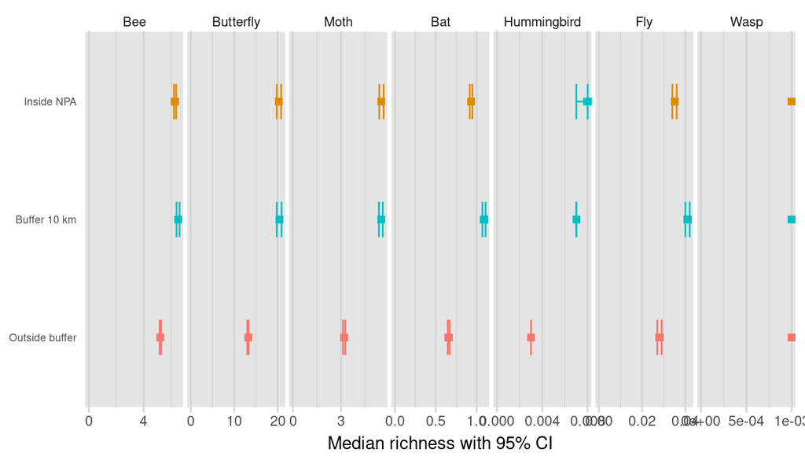

```r
# Plot
(
  p_anp <- medians_anp %>%
    plot_pollin_facet(
      var2 = 'pol_group',
      grp_var = grp_var,
      cols_var = 'pol_group',
      facet_scales = 'free_x'
    ) +
    facet_grid(
      cols = vars(pol_group),
      scales = 'free_x',
      labeller = labeller(
        biome = ~ str_replace(.x, ' ', '\n'),
        pol_group = ~ str_to_title(.x)
      )
    ) +
    scale_x_continuous(n.breaks= 3) +
    expand_limits(x=0) +
    bees_theme() +
    theme(plot.title = element_blank())
)
```

```r
# Save figure
ggsave_19cm(str_c(tools::file_path_sans_ext(grp_diffs_fp), '.png'),
                p_anp,
                height = 4,
            overwrite = TRUE)
```

#### Compare ANP zones within each biome

```r
grp_var <- 'anp_zone'
var2 <- NA

# File name
var2_code <- ifelse(is.na(var2), '',
                    str_c(str_remove_all(var2, '_.*'), '_'))
grp_var_code <- str_remove_all(grp_var, '_.*')
grp_diffs_fp <- file.path(samp_dir,
                          str_c('grpdiffs_', fn_prefix, '_',
            var2_code, grp_var_code, '.rds'))
medians_anp <- iterate_get_grp_diffs(df_samp, grp_var, var2, grp_diffs_fp, overwrite=TRUE)
```

[output not shown]

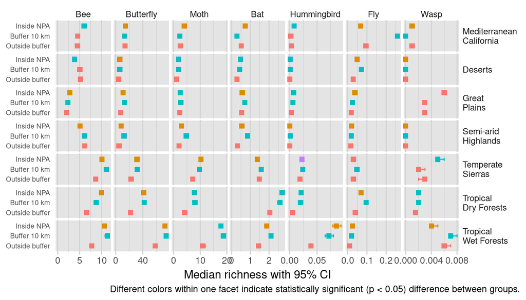

```r
# Plot
(
  p_anp <- medians_anp %>%
    plot_pollin_facet(
      'All',
      var2 = 'pol_group',
      grp_var = grp_var,
      rows_var = 'biome',
      cols_var = 'pol_group',
      facet_scales = 'free_x'
    ) +
    facet_grid(
      vars(biome),
      vars(pol_group),
      scales = 'free_x',
      labeller = labeller(
        biome = ~ str_replace(.x, ' ', '\n'),
        pol_group = ~ str_to_title(.x)
      )
    ) +
    scale_x_continuous(n.breaks= 3) +
    expand_limits(x=0) +
    labs(caption = caption) +
    bees_theme() +
    theme(plot.title = element_blank())
)
```

```r
# Save figure
ggsave_19cm(str_c(tools::file_path_sans_ext(grp_diffs_fp), '_polxbiome.png'),
                p_anp,
                height = 10,
            overwrite = TRUE)
```

#### Just look at bees

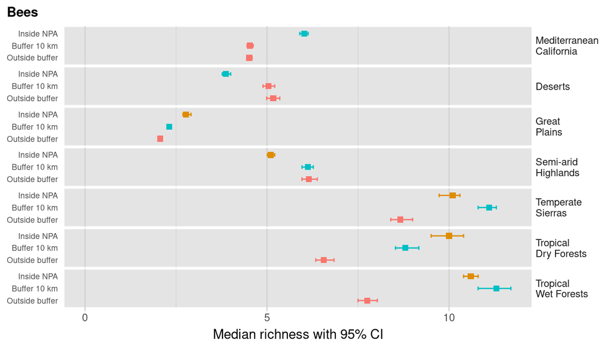

```r
# Plot only bees
(
  p_bees <- medians_anp %>%
  filter(pol_group == 'bee') %>%
    plot_pollin_facet(
      'Bees',
      var2 = 'pol_group',
      grp_var = grp_var
    ) +
    facet_grid(
      vars(biome),
      vars(pol_group),
      labeller = labeller(
        biome = ~ str_replace(.x, ' ', '\n'),
        pol_group = ~ str_to_title(.x)
      )
    ) +
    scale_x_continuous(n.breaks= 3) +
    expand_limits(x=0) +
    bees_theme() +
    theme(strip.text.x = element_blank())
)
```

```r
# Save figure
ggsave_19cm(str_c(tools::file_path_sans_ext(grp_diffs_fp), '_bees.png'),
                p_bees,
                width = 8,
            height = 13,
            overwrite = TRUE)
```

### Compare bee subgroups

```r
# Load stacked zones
combo_ras <- terra::rast(zones_ras_fp)

rich_dir <- file.path(pred_dir, 'richness', 'bee_subgroups')
bees_df <- create_richness_df(rich_dir, div_dir, zones_lu_fp, combo_ras, overwrite = FALSE)
bees_df <- bees_df %>%
  mutate(
    pol_group = factor(
      pol_group,
      levels = c(
        'social',
        'solitary-social',
        'solitary',
        'above-ground',
        'stems',
        'cavities',
        'ground'
      )
    ),
    grouper = ifelse(
      pol_group %in% c('social', 'solitary-social', 'solitary'),
      'by sociality',
      'by nesting'
    ),
    biome = factor(biome, levels = bioms_english_sorted)
  )

# Stratified random sample
(n_pols <- length(levels(bees_df$pol_group)))
```

```
## [1] 7
```

```r
fn_prefix <- str_c('rf', rf_vers, '_', n_pols, 'beegroups')
samp_fp <- file.path(samp_dir, str_c(fn_prefix, '.rds'))
df_samp <- sample_df(bees_df, samp_n, samp_fp,
                     grp_vars = c('anp_zone', 'biome', 'landcover'),
                     overwrite = FALSE)
```

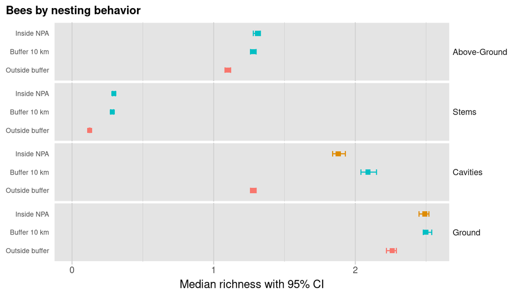

```r
grp_var <- 'anp_zone'
var2 <- NA
by_biome <- FALSE

# File name
var2_code <- ifelse(is.na(var2), '', str_c(str_remove_all(var2, '_.*'), '_'))
grp_var_code <- str_remove_all(grp_var, '_.*')
by_biom_code <- ifelse(by_biome, '', 'noBiome_')
grp_diffs_fp <- file.path(samp_dir,
                          str_c('grpdiffs_', fn_prefix, '_', by_biom_code, var2_code, grp_var_code, '.rds'))

# Get group medians and significance
medians_anp <- iterate_get_grp_diffs(df_samp, grp_var, var2, grp_diffs_fp,
                                     by_biome = by_biome,
                                     overwrite = TRUE)
medians_anp <- medians_anp %>%
  mutate(
    grouper = ifelse(
      pol_group %in% c('social', 'solitary-social', 'solitary'),
      'by sociality',
      'by nesting'
    )
  )

# Plot
(p_nest <- medians_anp %>%
    filter(grouper == 'by nesting') %>%
    plot_pollin_facet(
      title = 'Bees by nesting behavior',
      var2 = 'pol_group',
      grp_var = grp_var,
      rows_var = 'pol_group',
      facet_scales = 'free_x'
    ) +
    facet_grid(
      rows = vars(pol_group),
      labeller = labeller(
        biome = ~ str_replace(.x, ' ', '\n'),
        pol_group = ~ str_to_title(.x)
      )
    ) +
    scale_x_continuous(n.breaks= 3) +
    expand_limits(x=0) +
    bees_theme()
)
```

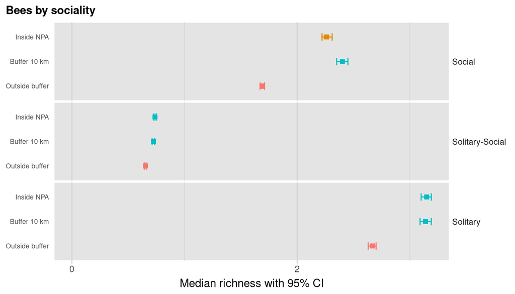

```r
# Save figure
ggsave_19cm(str_c(tools::file_path_sans_ext(grp_diffs_fp), '_nesting.png'),
                p_nest,
                width = 8,
            height = 7,
            overwrite = TRUE)

 # Plot by sociality
(p_soc <- medians_anp %>%
    filter(grouper == 'by sociality') %>%
    plot_pollin_facet(
      title = 'Bees by sociality',
      var2 = 'pol_group',
      grp_var = grp_var,
      rows_var = 'pol_group',
      facet_scales = 'free_x'
    ) +
    facet_grid(
      rows = vars(pol_group),
      labeller = labeller(
        biome = ~ str_replace(.x, ' ', '\n'),
        pol_group = ~ str_to_title(.x)
      )
    ) +
    scale_x_continuous(n.breaks= 3) +
    expand_limits(x=0) +
    bees_theme()
)
```

```r
# Save figure
ggsave_19cm(str_c(tools::file_path_sans_ext(grp_diffs_fp), '_sociality.png'),
                p_soc,
                width = 8,
            height = 6,
            overwrite = TRUE)
```

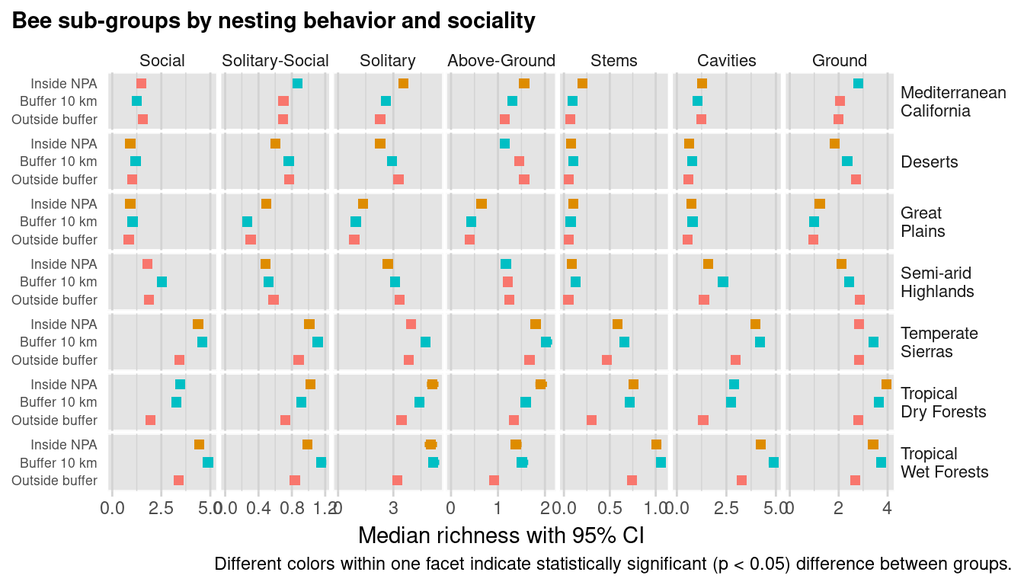

```r
grp_var <- 'anp_zone'
grp_var_code <- 'ANPzone'
var2 <- NA
var2_code <- 'noLC'

# File name
fn <- str_c('grpdiffs_', fn_prefix, '_', var2_code, '_', grp_var_code, '.rds')
grp_diffs_fp <- file.path(samp_dir, fn)
medians_anp <- iterate_get_grp_diffs(df_samp, grp_var, var2, grp_diffs_fp, overwrite=TRUE)
medians_anp <- medians_anp %>%
  mutate(
    grouper = ifelse(
      pol_group %in% c('social', 'solitary-social', 'solitary'),
      'by sociality',
      'by nesting'
    )
  )

# Plot
(p_beegroups <- medians_anp %>%
  plot_pollin_facet('Bee sub-groups by nesting behavior and sociality',
                    var2='pol_group', grp_var=grp_var,
                    rows_var = 'biome', cols_var = 'pol_group',
                    facet_scales = 'free_x') +
      facet_grid(vars(biome), vars(pol_group),
               scales = 'free_x',
               labeller = labeller(biome = ~ str_replace(.x, ' ', '\n'),
                                   pol_group = ~ str_to_title(.x))) +
    scale_x_continuous(n.breaks= 3) +
    labs(caption = caption) +
    bees_theme()
    )
```

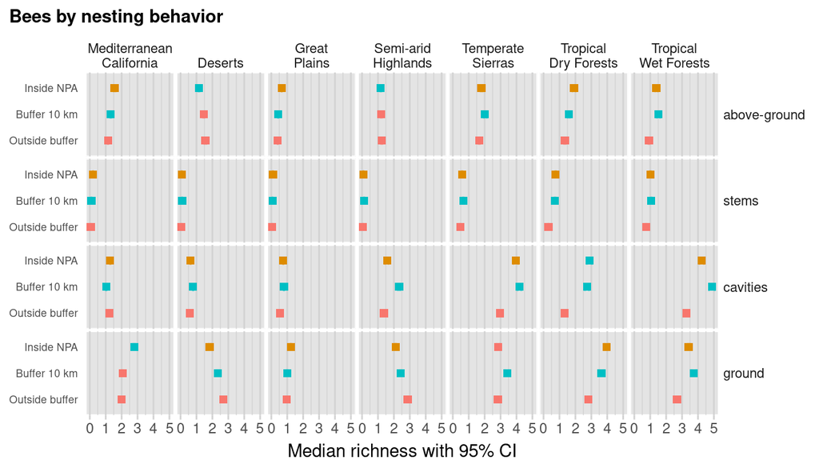

```r
# Save figure
ggsave_19cm(str_c(tools::file_path_sans_ext(grp_diffs_fp), '_polxbiome.png'),
            p_beegroups, height = 10, overwrite = TRUE)

# Bees by nesting behavior
(p_bynesting <- medians_anp %>%
  filter(pol_group %in% c('above-ground', 'cavities', 'ground', 'stems')) %>%
  plot_pollin_facet('Bees by nesting behavior', var2='pol_group', grp_var=grp_var) +
      facet_grid(vars(pol_group), vars(biome),
               # scales = 'free_x',
               labeller = labeller(biome = ~ str_replace(.x, ' ', '\n'))) +
  bees_theme())
```

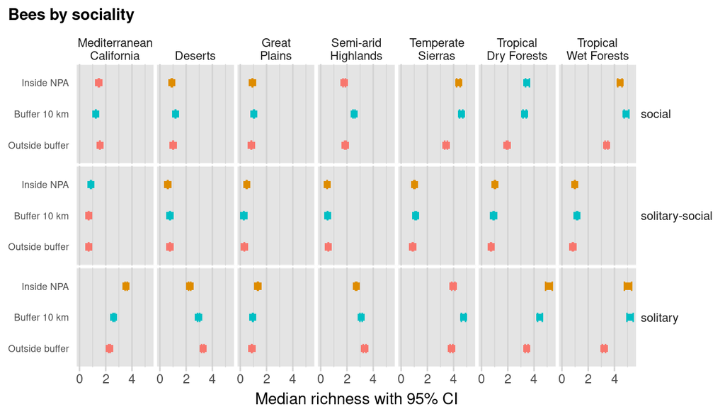

```r
# Save figure
ggsave_19cm(str_c(tools::file_path_sans_ext(grp_diffs_fp), '_beesnesting.png'),
            p_bynesting, height = 7, overwrite = TRUE)

# Plot only bees
(p_bysocial <- medians_anp %>%
  filter(pol_group %in% c('social', 'solitary', 'solitary-social')) %>%
  plot_pollin_facet('Bees by sociality', var2='pol_group', grp_var=grp_var) +
      facet_grid(vars(pol_group), vars(biome),
               # scales = 'free_x',
               labeller = labeller(biome = ~ str_replace(.x, ' ', '\n'))) +
  bees_theme())
```

```r
# Save figure
ggsave_19cm(str_c(tools::file_path_sans_ext(grp_diffs_fp), '_beessocial.png'),
            p_bysocial, height = 6, overwrite = TRUE)
```

### Compare all pollinators using land cover

#### Compare by landcover and NPA zone

```r
grp_var <- 'landcover'
var2 <- 'anp_zone'
var2_code <- 'ANPzone'

# File name
fn <- str_c('grpdiffs_', fn_prefix, '_', var2_code, '_', grp_var, '.rds')
grp_diffs_fp <- file.path(samp_dir, fn)
sum2 <- iterate_get_grp_diffs(df_samp, grp_var, var2, grp_diffs_fp, overwrite=TRUE)
sum2 <- sum2 %>% mutate(biome = factor(biome, levels = bioms_english_sorted))
```

```r
# Plot just one
pol_grp <- 'bee'
(
  p_bees <- sum2 %>%
    filter(pol_group == pol_grp) %>%
    plot_pollin_facet(str_to_title(pol_grp), var2 = var2, grp_var = grp_var)  +
    facet_grid(
      vars(anp_zone),
      vars(biome),
      labeller = labeller(
        biome = ~ str_replace(.x, ' ', '\n'),
        pol_group = ~ str_to_title(.x)
      )
    ) +
    labs(caption = caption) +
    bees_theme()
)

# Save figure
ggsave_19cm(str_c(tools::file_path_sans_ext(grp_diffs_fp), '_bees.png'),
            p_bees, height = 6, overwrite = TRUE)

# Plot
pol_grp <- 'hummingbird'
p_birds <- sum2 %>%
  filter(pol_group == pol_grp) %>%
  plot_pollin_facet(str_to_title(pol_grp), var2=var2, grp_var=grp_var)

pol_grp <- 'moth'
p_moths <- sum2 %>% filter(pol_group == pol_grp) %>%
  plot_pollin_facet(str_to_title(pol_grp), var2=var2, grp_var=grp_var)

pol_grp <- 'butterfly'
p_butterflies <- sum2 %>% filter(pol_group == pol_grp) %>%
  plot_pollin_facet(str_to_title(pol_grp), var2=var2, grp_var=grp_var)

pol_grp <- 'fly'
p_flies <- sum2 %>% filter(pol_group == pol_grp) %>%
  plot_pollin_facet(str_to_title(pol_grp), var2=var2, grp_var=grp_var)

pol_grp <- 'wasp'
p_wasps <- sum2 %>% filter(pol_group == pol_grp) %>%
  plot_pollin_facet(str_to_title(pol_grp), var2=var2, grp_var=grp_var)

pol_grp <- 'bat'
p_bats <- sum2 %>% filter(pol_group == pol_grp) %>%
  plot_pollin_facet(str_to_title(pol_grp), var2=var2, grp_var=grp_var)

# Put the plots together
plots <- list(p_bees + theme(strip.text.x = element_text(size=rel(0.8))),
              p_birds + theme(strip.text.x = element_text(size=rel(0.8))),
              p_butterflies,
              p_bats,
              p_moths + theme(axis.title.x = element_text()),
              p_wasps,
              guide_area(),
              p_flies + theme(axis.title.x = element_text()))

p_lc <- wrap_plots(plots, ncol=2, guides = 'collect') +
  plot_annotation(caption = caption) &
  # scale_x_continuous(n.breaks=3,
  #                    limits = c(0, 10)) &
  theme(plot.title.position = 'plot',
        legend.box = 'horizontal',
        legend.position = 'right',
        axis.text.x = element_text(margin = margin(t = .2, unit = "mm"),
                                   hjust = c(0, 0.5, 1) ))

# Save figure
ggsave_19cm(str_c(tools::file_path_sans_ext(grp_diffs_fp), '.png'),
            p_lc, height = 13, overwrite = TRUE)
```

[output not shown]

#### Compare by NPA zone and landcover

```r
grp_var <- 'anp_zone'
grp_var_code <- 'ANPzone'
var2 <- 'landcover'

# File name
fn <- str_c('grpdiffs_', fn_prefix, '_', var2, '_', grp_var_code, '.rds')
grp_diffs_fp <- file.path(samp_dir, fn)
sum2 <- iterate_get_grp_diffs(df_samp, grp_var, var2, grp_diffs_fp, overwrite=FALSE)
```

```r
# Plot just one
pol_grp <- 'bee'
p_bees <- sum2 %>%
  filter(pol_group == pol_grp) %>%
  plot_pollin_facet(str_to_title(pol_grp), var2=var2, grp_var=grp_var)

# Save figure
ggsave_19cm(str_c(tools::file_path_sans_ext(grp_diffs_fp), '_bees.png'),
            p_bees, height = 6, overwrite = TRUE)

# Plot
pol_grp <- 'hummingbird'
p_birds <- sum2 %>%
  filter(pol_group == pol_grp) %>%
  plot_pollin_facet(str_to_title(pol_grp), var2=var2, grp_var=grp_var)

pol_grp <- 'moth'
p_moths <- sum2 %>% filter(pol_group == pol_grp) %>%
  plot_pollin_facet(str_to_title(pol_grp), var2=var2, grp_var=grp_var)

pol_grp <- 'butterfly'
p_butterflies <- sum2 %>% filter(pol_group == pol_grp) %>%
  plot_pollin_facet(str_to_title(pol_grp), var2=var2, grp_var=grp_var)

pol_grp <- 'fly'
p_flies <- sum2 %>% filter(pol_group == pol_grp) %>%
  plot_pollin_facet(str_to_title(pol_grp), var2=var2, grp_var=grp_var)

pol_grp <- 'wasp'
p_wasps <- sum2 %>% filter(pol_group == pol_grp) %>%
  plot_pollin_facet(str_to_title(pol_grp), var2=var2, grp_var=grp_var)

pol_grp <- 'bat'
p_bats <- sum2 %>% filter(pol_group == pol_grp) %>%
  plot_pollin_facet(str_to_title(pol_grp), var2=var2, grp_var=grp_var)

# Put the plots together
plots <- list(p_bees + theme(strip.text.x = element_text(size=rel(0.8))),
              p_birds + theme(strip.text.x = element_text(size=rel(0.8))),
              p_butterflies,
              p_bats,
              p_moths + theme(axis.title.x = element_text()),
              p_wasps,
              guide_area(),
              p_flies + theme(axis.title.x = element_text()))

p_anplc <- wrap_plots(plots, ncol=2, guides = 'collect') +
  plot_annotation(caption = caption) &
  # scale_x_continuous(n.breaks=3,
  #                    limits = c(0, 10)) &
  theme(plot.title.position = 'plot',
        legend.box = 'horizontal',
        legend.position = 'right',
        axis.text.x = element_text(margin = margin(t = .2, unit = "mm"),
                                   hjust = c(0, 0.5, 1) ))

# Save figure
ggsave_19cm(str_c(tools::file_path_sans_ext(grp_diffs_fp), '.png'),
            p_anplc, height = 10, overwrite = TRUE)
```